# Heart rate detection and stress analysis

Tamas Nagy

2022-07-26

# Project setup

```r
# Set parameters
outlier_treshold_sd = 3 # Threshold for outliers in SD
# Column order for model summaries
col_order <- c("est",
               # "ci",
               "se",
               # "df.error",
               "stat",
               "p")

renamed_markers <-
  c("baseline" = "Baseline",
    "physical" = "Handgrip",
    "cognitive" = "N-back",
    "mental" = "N-back")

cardioceptive_names <-
  c(ca = "Heartbeat perception",
    hrp = "Heart rate perception")

phys_metrics <-
  tribble(~name, ~metric,
         "meanhr", "Mean HR",
         "lg_hf_percent", "HF% (log)",
         "lg_rmssd", "RMSSD (log)",
         "lg_eda_avg", "Mean EDA (log)",
         "hf.percent", "HF%",
         "rmssd", "RMSSD",
         "eda.avg", "Mean EDA") %>%
  mutate(metric = fct_inorder(metric))

skin_avg <- c("lg_eda_avg", "lg_scl_avg", "lg_scr_avg")
skin_increase <- c("eda_increase", "scl_increase", "scr_increase")
heart_metrics <- c("lg_rmssd", "lg_hf_percent", "lg_hf_n_u", "meanhr")


react_vars <-
   c(
      "meanhr_N-back",
      "meanhr_Handgrip",
      "hf.percent_N-back",
      "hf.percent_Handgrip",
      "rmssd_N-back",
      "rmssd_Handgrip",
      "eda.avg_N-back",
      "eda.avg_Handgrip",
      "stai_N-back",
      "stai_Handgrip"
   )
```

```css
.main-container {
    max-width: 100%;
}
```

The following analysis report contains the descriptive and inferential statistics for the experiment that investigated how physiological and subjective arousal might be mediated by cardioceptive accuracy.

# Read data

```r
phys_trans <-
  read_csv(here::here("data/processed/physiology_clean.csv"))

experiment <-
  read_csv(here::here("data/processed/survey_clean.csv"))

reactivity <-
  read_csv(here::here("data/processed/reactivity_clean.csv"))
```

# Sample characteristics

```r
experiment %>%
  select(male = sex,
         age,
         stai_s_t0_sum,
         bmi,
         bodyfat_percent,
         max_grip_strength,
         resting_hr) %>%
  mutate(male = if_else(male == "Male", 100, 0),
         n = n(),
         .before = 1) %>%
  skim() %>%
  select( name = skim_variable,
          mean = numeric.mean,
          sd = numeric.sd,
          min = numeric.p0,
          max = numeric.p100,
          Distribution = numeric.hist) %>%
  mutate(name = c("N",
                  "Male %",
                  "Mean age (years)",
                  "Mean STAI-S baseline",
                  "Mean BMI (kg/m<sup>2</sup>)",
                  "Mean bodyfat %",
                  "Mean max grip strength (kg)",
                  "Mean resting HR (bpm)")) %>%
  gt() %>%
  fmt_number(c(mean, sd, min, max), decimals = 1, rows = 2:8) %>%
  fmt_markdown(columns = 1) %>%
  cols_merge(columns = c("mean", "sd"), pattern = "{1} ({2})") %>%
  cols_merge(columns = c("min", "max"), pattern = "{1} - {2}") %>%
  cols_label("name" = "",
             "mean" = "Value (SD)",
             "min" = "Range")
```

|  | Value (SD) | Range | Distribution |
| --- | --- | --- | --- |
| N | 67 (0) | 67 - 67 | ▁▁▇▁▁ |
| Male % | 50.7 (50.4) | 0.0 - 100.0 | ▇▁▁▁▇ |
| Mean age (years) | 22.2 (2.2) | 19.0 - 28.0 | ▆▇▃▃▁ |
| Mean STAI-S baseline | 13.0 (7.5) | 0.0 - 33.0 | ▃▇▃▂▁ |
| Mean BMI (kg/m<sup>2</sup>) | 23.1 (3.2) | 17.8 - 31.5 | ▅▇▅▂▂ |
| Mean bodyfat % | 24.2 (8.3) | 5.2 - 49.0 | ▂▇▇▃▁ |
| Mean max grip strength (kg) | 33.7 (10.6) | 17.1 - 65.0 | ▇▆▇▂▁ |
| Mean resting HR (bpm) | 76.8 (10.7) | 54.0 - 101.0 | ▂▆▇▆▂ |

# Subjective response to stress: STAI-S

Controlling for the baseline level of anxiety (measured in the beginning of the session) and the order of the tasks, we found a significant interaction of task and measurement, i.e. the cognitive task was associated with a STAI-S increase over time, while the physical task did not show a significant change.

```r
stai <-
   experiment %>%
   select(id, ends_with("_sum"), task_order) %>%
   pivot_longer(cols = -c(id, stai_s_t0_sum, task_order),
                names_to = c("task", "time"),
                names_pattern = "stai_s_(.*)_(.*)_sum") %>%
   mutate(task = recode(task, !!!renamed_markers))

stai_sum <-
   stai %>%
   group_by(task, time) %>%
   summarise(stai_avg = mean(value, na.rm = TRUE),
             stai_sd = sd(value, na.rm = TRUE),
             stai_se = stai_sd/sqrt(n())) %>%
   mutate(stai_prop = stai_avg/first(stai_avg)) %>%
   ungroup()

# Table
stai_sum %>%
   select(-stai_se) %>%
   pivot_wider(names_from = c(time), names_sep = "_",
               values_from = c(stai_avg, stai_sd, stai_prop)) %>%
   select(-stai_prop_t0) %>%
   gt() %>%
   fmt_number(columns = starts_with("stai_"),
                 decimals = 1) %>%
   fmt_percent(stai_prop_t1, decimals = 1) %>%
   cols_merge(columns = ends_with("_t0"),
              pattern = "{1} ± {2}") %>%
   cols_merge(columns = ends_with("_t1"),
              pattern = "{1} ± {2} ({3})") %>%
   cols_label(task = "Task",
              stai_avg_t0 = "Pre-stress",
              stai_avg_t1 = "Post-stress") %>%
   tab_options(column_labels.font.weight = "bold",
               column_labels.background.color = "lightgrey") %>%
   tab_footnote(footnote = "Values represent the mean (SD) of the STAI-S",
                locations = cells_column_labels(3))
```

| Task | Pre-stress | Post-stress<sup>1</sup> |
| --- | --- | --- |
| Handgrip | 11.4 ± 7.4 | 11.0 ± 6.8 (1.0) |
| N-back | 10.9 ± 6.8 | 14.0 ± 7.8 (1.3) |

<sup>1</sup> Values represent the mean (SD) of the STAI-S

```r
# Stats
stai %>%
   filter(task != "baseline") %>%
   lmer(value ~ task * time + stai_s_t0_sum + task_order + (1|id),
        data = .) %>%
   tab_model(dv.labels = "STAI-S",
             show.aicc = TRUE,
             show.stat = TRUE,
             show.df = TRUE,
             show.std = TRUE)
```

|  | STAI-S |  |  |  |  |  |  |
| --- | --- | --- | --- | --- | --- | --- | --- |
| Predictors | Estimates | std. Beta | CI | standardized CI | Statistic | p | df |
| (Intercept) | 1.27 | -0.08 | -0.84 – 3.38 | -0.26 – 0.10 | 1.18 | 0.238 | 255.00 |
| task [N-back] | -0.58 | -0.08 | -1.62 – 0.47 | -0.22 – 0.06 | -1.08 | 0.280 | 255.00 |
| time [t1] | -0.42 | -0.06 | -1.47 – 0.62 | -0.20 – 0.09 | -0.80 | 0.426 | 255.00 |
| stai s t0 sum | 0.77 | 0.78 | 0.65 – 0.88 | 0.66 – 0.90 | 12.67 | **<0.001** | 255.00 |
| task order [Physical first] | 0.61 | 0.08 | -1.19 – 2.41 | -0.16 – 0.33 | 0.67 | 0.504 | 255.00 |
| task [N-back] * time [t1] | 3.57 | 0.49 | 2.09 – 5.06 | 0.29 – 0.70 | 4.74 | **<0.001** | 255.00 |
| Random Effects |  |  |  |  |  |  |  |
| σ<sup>2</sup> | 9.35 |  |  |  |  |  |  |
| τ<sub>00</sub> <sub>id</sub> | 10.54 |  |  |  |  |  |  |
| ICC | 0.53 |  |  |  |  |  |  |
| N <sub>id</sub> | 66 |  |  |  |  |  |  |
| Observations | 263 |  |  |  |  |  |  |
| Marginal R<sup>2</sup> / Conditional R<sup>2</sup> | 0.628 / 0.825 |  |  |  |  |  |  |
| AICc | 1458.007 |  |  |  |  |  |  |

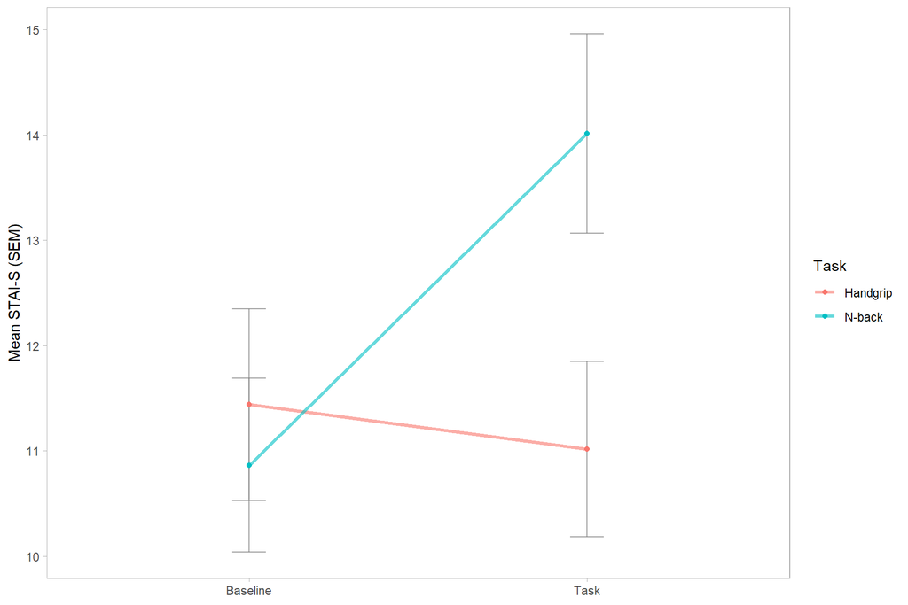

```r
# Visualize
stai_sum %>%
   mutate(time = recode(time, t0 = "Baseline", t1 = "Task")) %>%
   ggplot() +
   aes(x = time,
       y = stai_avg,
       group = task,
       color = task,
       ymin = stai_avg - stai_se,
       ymax = stai_avg + stai_se) +
   geom_errorbar(width = .1, alpha = .7, color = "gray50") +
   geom_point() +
   geom_line(size = 1.2, alpha = .6) +
   # scale_y_continuous(limits = c(0, NA)) +
   labs(color = "Task",
        # title = "Change in STAI-S by task and time",
        # subtitle = "STAI-S increased only in the cognitive stress task.",
        y = "Mean STAI-S (SEM)",
        x = NULL) +
  theme(panel.grid = element_blank())
```

# Psychophysiological response to stress

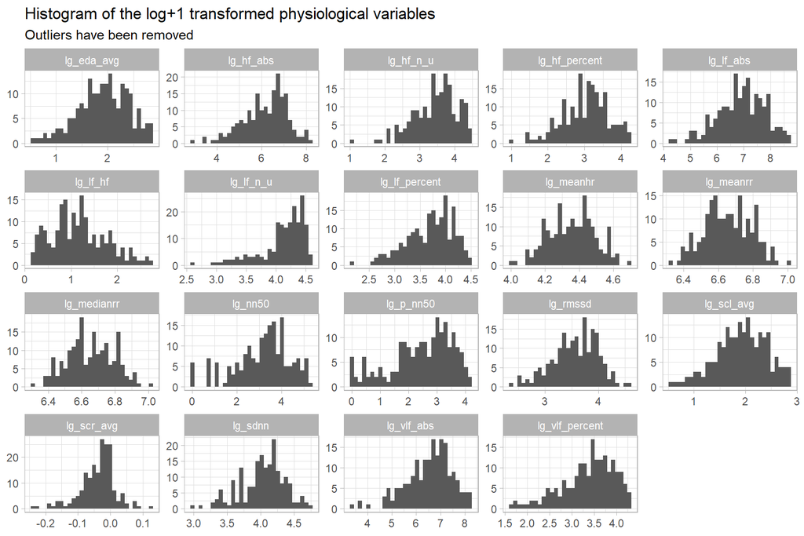

```r
phys_trans %>%
   select(starts_with("lg_")) %>%
   pivot_longer(everything()) %>%
   ggplot() +
   aes(x = value) +
   geom_histogram() +
   facet_wrap(~name, scales = "free") +
   labs(x = NULL, y = NULL,
        title = "Histogram of the log+1 transformed physiological variables",
        subtitle = "Outliers have been removed")
```

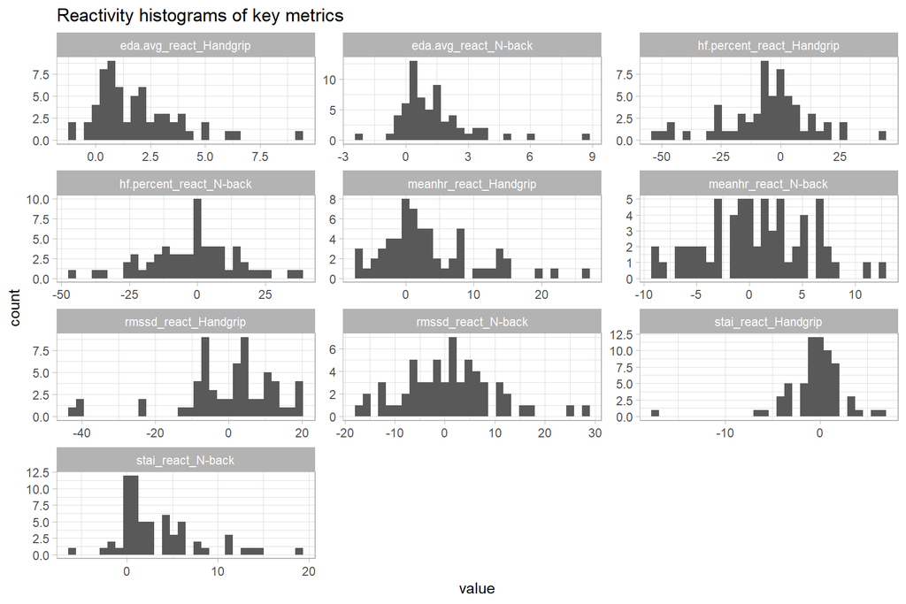

```r
reactivity %>%
   pivot_longer(-id) %>%
   ggplot() +
   aes(x = value) +
   geom_histogram() +
   facet_wrap(~name, scales = "free", nrow = 4) +
   labs(title = "Reactivity histograms of key metrics")
```

# Analysis of the effects of the tasks on physiological variables

# Descriptive statistics

```r
phys_trans %>%
  select(id, marker, ca, hrp,
         meanhr, lg_hf_percent, lg_rmssd, lg_eda_avg) %>%
  summarise(across(ca:lg_eda_avg,
                   list(mean = mean, sd = sd),
                   na.rm = TRUE)) %>%
  pivot_longer(everything(),
               names_to = c("name", "stat"),
               names_pattern = "^(.*)_(.*)$") %>%
  pivot_wider(names_from = "stat") %>%
  left_join(phys_metrics, by = "name") %>%
  relocate(metric) %>%
  gt() %>%
  fmt_number(mean:sd, decimals = 2)
```

| metric | name | mean | sd |
| --- | --- | --- | --- |
| NA | ca | 0.54 | 0.27 |
| NA | hrp | 0.93 | 0.13 |
| Mean HR | meanhr | 77.90 | 10.61 |
| HF% (log) | lg_hf_percent | 3.02 | 0.63 |
| RMSSD (log) | lg_rmssd | 3.56 | 0.42 |
| Mean EDA (log) | lg_eda_avg | 1.92 | 0.49 |

## Heart rate related variables

### Variables

Heart rate and HRV variables were investigated using linear mixed-effect models, with random intercept by person. HRV variables were log+1 transformed to correct for right skew.

### Results

```r
phys_trans %>%
   select(id, marker, task_order, sex, bodyfat_percent,
          all_of(phys_metrics$name[1:4])) %>%
   pivot_longer(all_of(phys_metrics$name[1:4])) %>%
   group_by(name) %>%
   nest() %>%
   mutate(model = map(data,
                      ~lmer(value ~ marker +
                            task_order + sex + scale(bodyfat_percent) + (1|id),
                            data = .x))) %>%
   pull(model) %>%
   set_names(phys_metrics$name[1:4]) %>%
   tab_model(dv.labels = phys_metrics$metric[1:4],
             pred.labels = c("(Intercept)",
                             "Task [N-back]",
                             "Task [Handgrip]",
                             "Task order [Physical first]",
                             "Sex [Male]",
                             "Bodyfat %"),
             string.stat = "t",
             string.ci = "95% CI",
             # file = "tables/phys_change.html",
             show.stat = TRUE
             )
```

[output not shown]

## Visualize phys changes

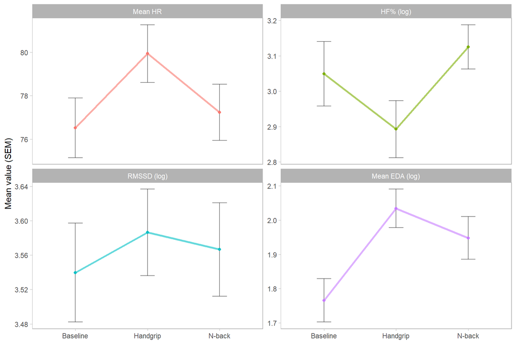

```r
phys_trans %>%
   select(id, marker, task_order, sex, bodyfat_percent,
          meanhr, lg_hf_percent, lg_rmssd, lg_eda_avg) %>%
   pivot_longer(meanhr:lg_eda_avg, values_drop_na = TRUE) %>%
   left_join(phys_metrics, by = "name") %>%
   group_by(metric, marker) %>%
   summarise(avg_value = mean(value),
             se_value = sd(value)/sqrt(n()),
             .groups = "drop") %>%
   ggplot() +
   aes(x = marker, y = avg_value, group = metric,
       ymin = avg_value - se_value, ymax = avg_value + se_value) +
   geom_errorbar(width = .2, alpha = .5) +
   geom_point(aes(color = metric), show.legend = FALSE) +
   geom_line(aes(color = metric),
             size = 1.2, alpha = .6,
             show.legend = FALSE) +
   facet_wrap(~metric, scales = "free_y") +
   labs(y = "Mean value (SEM)",
        x = NULL) +
   theme(panel.grid = element_blank())
```

## Change stats in %

```r
phys_trans %>%
  select(id, marker, one_of(phys_metrics$name[1:4])) %>%
  pivot_longer(-c(id, marker)) %>%
  group_by(name, marker) %>%
  summarise(avg = mean(value, na.rm = TRUE),
            sd = sd(value, na.rm = TRUE)) %>%
  mutate(prop_change = avg / first(avg) %>% round(2)) %>%
  ungroup() %>%
  pivot_wider(names_from = marker,
              values_from = c(avg, sd, prop_change)) %>%
  left_join(phys_metrics, by = "name") %>%
  relocate(metric) %>%
  select(-name) %>%
  arrange(metric) %>%
  gt() %>%
  fmt_percent(starts_with("prop_"), decimals = 1) %>%
  fmt_number(matches("^avg.*|^sd.*"), decimals = 2) %>%
  cols_merge(columns = ends_with("_Baseline"),
             pattern = "{1} ± {2}") %>%
  cols_merge(columns = ends_with("_Handgrip"),
             pattern = "{1} ± {2} ({3})") %>%
  cols_merge(columns = ends_with("_N-Back"),
             pattern = "{1} ± {2} ({3})") %>%
  cols_label(metric = "",
             avg_Baseline = "Baseline",
             avg_Handgrip = "Handgrip",
             `avg_N-back` = "N-back") %>%
  cols_align(metric, align = "left")
```

|  | Baseline | Handgrip | N-back |
| --- | --- | --- | --- |
| Mean HR | 76.52 ± 10.92 | 79.94 ± 10.51 (104.5%) | 77.23 ± 10.24 (100.9%) |
| HF% (log) | 3.05 ± 0.71 | 2.89 ± 0.64 (94.8%) | 3.13 ± 0.50 (102.5%) |
| RMSSD (log) | 3.54 ± 0.45 | 3.59 ± 0.40 (101.3%) | 3.57 ± 0.42 (100.7%) |
| Mean EDA (log) | 1.77 ± 0.50 | 2.03 ± 0.45 (114.9%) | 1.95 ± 0.49 (110.0%) |

## Electrodermal response

### Variables

Raw electrodermal response was decomposed to tonic (SCL) and phasic (SCR) components. SCL was calculated by using the exponential moving average of the EDA values. The SCR values were calculated by taking the difference of EDA and SCL. We inspected the EDA, SCL, and SCR averages, and the increase value of these metrics. The averages were analyzed using linear mixed-effect models. The increase values are zero censored and heavily skewed, thus showing a gamma distribution. Therefore, we analyzed these values using generalized linear mixed-effect models, using a Gamma distribution with inverse link. Data had to be transformed to be applicable for statistical modeling. Average values were log+1 transformed and centered. Increase values were centered, then multiplied by 1000 for easier interpretation, then 1 is added to values to be larger than zero.

### Results

Sex, task order, and bodyfat percent were controlled, and were not significant predictors (age has little variability in the sample).

```r
# LMEMs for average values
skin_avg_mod <-
   phys_trans %>%
   select(id, task_order, marker, sex, bodyfat_percent,
          all_of(skin_avg)) %>%
   pivot_longer(all_of(skin_avg), values_drop_na = TRUE) %>%
   # Center values
   mutate(std_value = scale(value, scale = FALSE)) %>%
   group_by(name) %>%
   nest() %>%
   mutate(model = map(data, ~lmer(std_value ~ marker +
                                  task_order + sex + scale(bodyfat_percent) +
                                  (1|id),
                                  data = .x))) %>%
   pull(model) %>%
   set_names(skin_avg)

tab_model( skin_avg_mod,
           dv.labels = skin_avg,
           show.loglik = TRUE,
           show.aicc = TRUE)
```

|  | lg_eda_avg |  |  | lg_scl_avg |  |  | lg_scr_avg |  |  |
| --- | --- | --- | --- | --- | --- | --- | --- | --- | --- |
| Predictors | Estimates | CI | p | Estimates | CI | p | Estimates | CI | p |
| (Intercept) | 0.49 | 0.27 – 0.71 | **<0.001** | 0.50 | 0.28 – 0.72 | **<0.001** | -1.31 | -1.33 – -1.29 | **<0.001** |
| marker [Handgrip] | 0.27 | 0.21 – 0.33 | **<0.001** | 0.27 | 0.21 – 0.33 | **<0.001** | -0.02 | -0.04 – -0.01 | **0.009** |
| marker [N-back] | 0.18 | 0.12 – 0.24 | **<0.001** | 0.18 | 0.12 – 0.24 | **<0.001** | -0.00 | -0.02 – 0.02 | 0.832 |
| task order [Physical first] | -0.03 | -0.27 – 0.21 | 0.803 | -0.03 | -0.26 – 0.21 | 0.815 | -0.01 | -0.03 – 0.01 | 0.235 |
| sex [Male] | 0.03 | -0.28 – 0.33 | 0.851 | 0.02 | -0.28 – 0.33 | 0.872 | 0.02 | -0.00 – 0.04 | 0.051 |
| bodyfat percent | 0.11 | -0.04 – 0.26 | 0.158 | 0.11 | -0.04 – 0.26 | 0.164 | 0.01 | -0.00 – 0.02 | 0.257 |
| Random Effects |  |  |  |  |  |  |  |  |  |
| σ<sup>2</sup> | 0.03 |  |  | 0.03 |  |  | 0.00 |  |  |
| τ<sub>00</sub> | 0.20 <sub>id</sub> |  |  | 0.20 <sub>id</sub> |  |  | 0.00 <sub>id</sub> |  |  |
| ICC | 0.88 |  |  | 0.88 |  |  | 0.07 |  |  |
| N | 63 <sub>id</sub> |  |  | 63 <sub>id</sub> |  |  | 64 <sub>id</sub> |  |  |
| Observations | 189 |  |  | 189 |  |  | 187 |  |  |
| Marginal R<sup>2</sup> / Conditional R<sup>2</sup> | 0.089 / 0.894 |  |  | 0.090 / 0.894 |  |  | 0.070 / 0.134 |  |  |
| AICc | 86.376 |  |  | 85.973 |  |  | -506.669 |  |  |
| log-Likelihood | -34.788 |  |  | -34.587 |  |  | 261.739 |  |  |

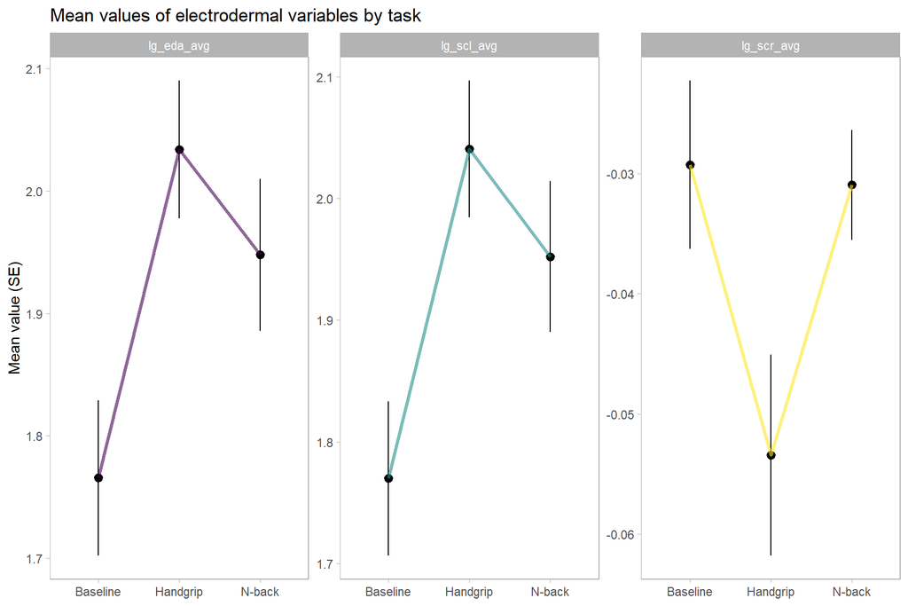

```r
phys_trans %>%
   select(id, marker, task_order, sex, bodyfat_percent,
          all_of(skin_avg)) %>%
   pivot_longer(all_of(skin_avg), values_drop_na = TRUE) %>%
   group_by(name, marker) %>%
   summarise(avg_value = mean(value),
             se_value = sd(value)/sqrt(n()),
             .groups = "drop") %>%
   ggplot() +
   aes(x = marker, y = avg_value, group = name,
       ymin = avg_value - se_value, ymax = avg_value + se_value) +
   geom_pointrange() +
   geom_line(aes(color = name), size = 1.2, alpha = .6, show.legend = FALSE) +
   scale_color_viridis_d() +
   facet_wrap(~name, scales = "free_y") +
   labs(title = "Mean values of electrodermal variables by task",
        y = "Mean value (SE)",
        x = NULL) +
  theme(panel.grid = element_blank())
```

## Reactivity measures

### Variables

Reactivity (task - baseline) values were calculated for EDA average, HF%, RMSSD, HR average, and STAI.

### Results

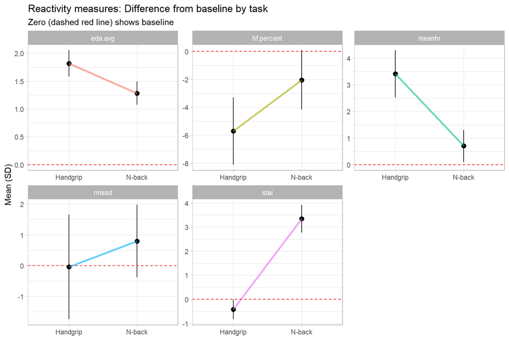

```r
reactivity %>%
   pivot_longer(-id, values_drop_na = TRUE) %>%
   group_by(name) %>%
   summarise(avg = mean(value),
             se = sd(value)/sqrt(n())) %>%
   separate(name,
            into = c("metric", "marker"),
            sep = "_",
            extra = "merge") %>%
   mutate(marker = str_remove_all(marker, "react_")) %>%
   ggplot() +
   aes(x = marker, y = avg, ymin = avg - se, ymax = avg + se,
       group = metric) +
   geom_pointrange() +
   geom_line(aes(color = metric), size = 1.2, alpha = .6,
             show.legend = FALSE) +
   geom_hline(yintercept = 0, color = "red", lty = "dashed") +
   facet_wrap(~metric, scales = "free") +
   labs(title = "Reactivity measures: Difference from baseline by task",
        subtitle = "Zero (dashed red line) shows baseline",
        x = NULL,
        y = "Mean (SD)")
```

# Hypothesis tests

## H1

There is a medium level association between cardioceptive accuracy [cardioceptive_accuracy] and cardiovascular reactivity (positive for heart rate [ΔHRmental, ΔHRphysical], electrodermal response [SCRmental; SCRphysical]; negative for vagal component of heart rate variability [ΔRMSSDmental, ΔHFmental; ΔRMSSDphysical, ΔHFphysical]) in both conditions (mental; physical)

We calculated the reactivity values, and correlated those with cardioceptive accuracy/bias, and heart rate perception.

```r
# More concise table
experiment %>%
   select(id, ca, hrp) %>%
   left_join(reactivity, by = "id") %>%
   rename_with(~str_remove(., "react_")) %>%
   correlation(p_adjust = "fdr",
               select2 = c("ca", "hrp"),
               select = all_of(react_vars)) %>%
   summary() %>%
   separate(Parameter, into = c("name", "task"), sep = "_") %>%
   left_join(phys_metrics, by = "name") %>%
   filter(!str_detect(name, "stai")) %>%
   relocate(task, metric) %>%
   select(-name) %>%
   arrange(task) %>%
   print_html() %>%
   cols_hide(1)
```

| task | metric | ca | hrp |
| --- | --- | --- | --- |
| Handgrip | Mean HR | -0.02 | 0.11 |
| Handgrip | HF% | -0.01 | 0.11 |
| Handgrip | RMSSD | -0.16 | -0.10 |
| Handgrip | Mean EDA | 0.13 | -0.02 |
| N-back | Mean HR | 0.01 | 0.15 |
| N-back | HF% | 0.08 | 0.08 |
| N-back | RMSSD | -0.17 | 0.02 |
| N-back | Mean EDA | 0.11 | 0.14 |

### Correlation between pooled physiological measurements and cardioceptive metrics

We did not find a relationship between cardioceptive accuracy and physiological reactivity measures (HR, RMSSD, HF%, EDA) in any of the tasks. However, CA was negatively associated with HR and positively with lgRMSSD. Similarly, heart rate perception was negatively associated with HR and positively with lgRMSSD, but did not moderate the reaction to stress.

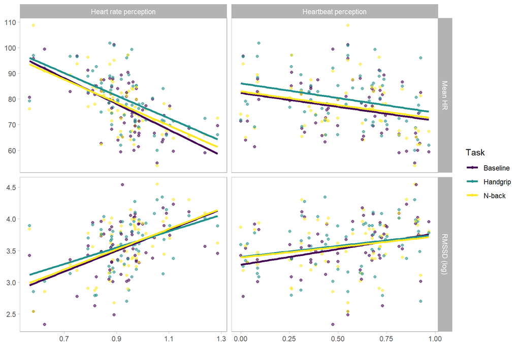

```r
phys_trans %>%
   select(meanhr, lg_rmssd, marker, hrp, ca) %>%
   pivot_longer(meanhr:lg_rmssd,
                names_to = "name",
                values_to = "value") %>%
   pivot_longer(hrp:ca,
                names_to = "cardio_metric",
                values_to = "cardio_value") %>%
   left_join(phys_metrics, by = "name") %>%
   mutate(cardio_metric = recode(cardio_metric, !!!cardioceptive_names)) %>%
   ggplot() +
   aes(x = cardio_value, y = value, color = marker) +
   geom_point(alpha = .6) +
   geom_smooth(method = "lm",
               size = 1.2,
               se = FALSE,
               alpha = .6) +
   scale_color_viridis_d() +
   labs(color = "Task",
        y = NULL,
        x = NULL) +
   facet_grid(metric ~ cardio_metric, scales = "free") +
   theme(panel.grid = element_blank())
```

## H2

Cardioceptive accuracy [cardioceptive_accuracy] moderates the association between objective [ΔHRmental, SCRmental, ΔRMSSDmental, ΔHFmental; ΔHRphysical, SCRphysical, ΔRMSSDphysical, ΔHFphysical] and subjective reactions to stress [mental_experienced_stress; physical_experienced_stress / STAI-S_mental_after – STAI-S_mental_before; STAI-S_physical_after - STAI-S_physical_before]; higher cardioceptive accuracy is related to a stronger association

We fitted linear regressions on the reactivity score for each metric (HR mean, HF%, RMSSD, and EDA mean) for each task (cognitive and physical). We investigated if the STAI-S change in the respective task had a significant association with the change metric, and if the cardioceptive accuracy or heart rate perception moderated the association. We included sex, body fat percent, and task order as covariates.

We found a significant negative association between the reactivity of EDA mean in the cognitive task and the change in STAI. The higher the perceived stress was, the more the EDA mean decreased in the cognitive task.

```r
hypo2 <-
   reactivity %>%
   # Put all reactivity metrics and cardioceptive metrics together
   left_join(select(experiment, id, ca, hrp, bodyfat_percent, hrp_group, sex, task_order), by = "id") %>%
   # Create a redundant dataset to run several regressions at once
   pivot_longer(-c(id, ca, hrp, hrp_group, bodyfat_percent, sex, `stai_react_N-back`, stai_react_Handgrip, task_order),
                names_to = c("metric","task"),
                names_pattern = "(.*)_react_(.*)") %>%
   group_by(metric, task) %>%
   # Scale all numeric vaiarables (by metric and task)
   mutate(across(c(`stai_react_N-back`:bodyfat_percent, value),
                 ~scale(.x) %>%
                  as.numeric())) %>%
   nest() %>%
   # Create several models for different cardioceptive metrics and tasks
   mutate(`ca_N-back_mod` = map(data,
                            ~lm(`stai_react_N-back` ~ value * ca +
                                        bodyfat_percent + sex + task_order,
                                data = .x)),
          `hrp_N-back_mod` = map(data,
                            ~lm(`stai_react_N-back` ~ value * hrp +
                                        bodyfat_percent + sex + task_order,
                                data = .x)),
          ca_Handgrip_mod = map(data,
                            ~lm(stai_react_Handgrip ~ value * ca +
                                         bodyfat_percent + sex + task_order,
                                data = .x)),
          hrp_Handgrip_mod = map(data,
                            ~lm(stai_react_Handgrip ~ value * hrp +
                                        bodyfat_percent + sex + task_order,
                                data = .x))
   ) %>%
   # Drop all models where the physiological and subjective task doesn't mach
   pivot_longer(`ca_N-back_mod`:hrp_Handgrip_mod) %>%
   filter((str_detect(task, "N-back") & str_detect(name, "N-back")) |
          (str_detect(task, "Handgrip") & str_detect(name, "Handgrip"))) %>%
   unite("metric_task", metric, task) %>%
   arrange(name)

# Print all models
hypo2 %>%
   pull(value) %>%
   set_names(hypo2$metric_task) %>%
   map(tidy, conf.int = TRUE) %>%
   map(~mutate(.x, cr = case_when(str_detect(term, "ca$") ~ "ca",
                                  str_detect(term, "hrp$") ~ "hrp"))) %>%
   map(~fill(.x, cr, .direction = "up")) %>%
   bind_rows(.id = "model") %>%
   separate(model, into = c("metric", "task"), sep = "_") %>%
   mutate(term = str_replace(term, "value", metric)) %>%
   group_by(metric, task, cr) %>%
   select(metric, task, cr, term, estimate, std.error,
          conf.low, conf.high,
          statistic, p.value) %>%
   # mutate(p.value = p.adjust(p.value, method = "fdr")) %>%
   gt() %>%
   fmt_number(c("estimate", "std.error", "statistic",
                "conf.low", "conf.high"
                ),
                decimals = 2) %>%
   fmt_number("p.value", decimals = 3) %>%
   tab_options(column_labels.font.weight = "bold",
               column_labels.background.color = "lightgrey",
               row_group.background.color = "lightgrey",
               row_group.font.weight = "bold",
               row.striping.include_table_body = TRUE,
               row.striping.background_color = "#EEEEEE"
   )
```

| term | estimate | std.error | conf.low | conf.high | statistic | p.value |
| --- | --- | --- | --- | --- | --- | --- |
| meanhr - Handgrip - ca |  |  |  |  |  |  |
| (Intercept) | 0.39 | 0.23 | −0.06 | 0.85 | 1.75 | 0.086 |
| meanhr | −0.12 | 0.12 | −0.36 | 0.13 | −0.96 | 0.343 |
| ca | 0.08 | 0.13 | −0.18 | 0.34 | 0.62 | 0.535 |
| bodyfat_percent | −0.33 | 0.17 | −0.66 | 0.00 | −1.98 | 0.052 |
| sexMale | −0.92 | 0.32 | −1.56 | −0.29 | −2.91 | 0.005 |
| task_orderPhysical first | 0.17 | 0.25 | −0.34 | 0.68 | 0.68 | 0.500 |
| meanhr:ca | −0.25 | 0.13 | −0.51 | 0.01 | −1.96 | 0.054 |
| hf.percent - Handgrip - ca |  |  |  |  |  |  |
| (Intercept) | 0.50 | 0.24 | 0.01 | 0.99 | 2.04 | 0.046 |
| hf.percent | −0.08 | 0.15 | −0.37 | 0.22 | −0.53 | 0.597 |
| ca | −0.02 | 0.13 | −0.27 | 0.24 | −0.12 | 0.904 |
| bodyfat_percent | −0.35 | 0.17 | −0.69 | −0.01 | −2.05 | 0.045 |
| sexMale | −0.94 | 0.33 | −1.60 | −0.28 | −2.84 | 0.006 |
| task_orderPhysical first | 0.04 | 0.27 | −0.50 | 0.58 | 0.14 | 0.890 |
| hf.percent:ca | 0.04 | 0.16 | −0.29 | 0.37 | 0.24 | 0.813 |
| rmssd - Handgrip - ca |  |  |  |  |  |  |
| (Intercept) | 0.49 | 0.23 | 0.03 | 0.96 | 2.13 | 0.038 |
| rmssd | −0.15 | 0.14 | −0.43 | 0.13 | −1.07 | 0.289 |
| ca | −0.05 | 0.13 | −0.30 | 0.20 | −0.41 | 0.683 |
| bodyfat_percent | −0.35 | 0.16 | −0.68 | −0.02 | −2.12 | 0.039 |
| sexMale | −0.93 | 0.32 | −1.58 | −0.29 | −2.91 | 0.005 |
| task_orderPhysical first | 0.03 | 0.26 | −0.49 | 0.54 | 0.10 | 0.922 |
| rmssd:ca | 0.03 | 0.14 | −0.25 | 0.31 | 0.23 | 0.820 |
| eda.avg - Handgrip - ca |  |  |  |  |  |  |
| (Intercept) | 0.47 | 0.24 | −0.01 | 0.96 | 1.94 | 0.057 |
| eda.avg | −0.08 | 0.15 | −0.38 | 0.22 | −0.51 | 0.613 |
| ca | 0.00 | 0.13 | −0.25 | 0.26 | 0.03 | 0.978 |
| bodyfat_percent | −0.40 | 0.17 | −0.74 | −0.07 | −2.40 | 0.020 |
| sexMale | −0.97 | 0.35 | −1.66 | −0.27 | −2.79 | 0.007 |

[output cut: 98 more lines]

```r
# Model values
hypo2 %>%
   pull(value) %>%
   set_names(paste(str_match(hypo2$name, "^(\\w+)_.*_mod")[,2],
                   hypo2$metric_task,
                   sep = "_"
                   )) %>%
   map_dfr(glance, .id = "model") %>%
   select(model:adj.r.squared, statistic:BIC, df.residual) %>%
   relocate(df.residual, .after = df) %>%
   gt() %>%
   fmt_number(c("r.squared", "adj.r.squared", "statistic",
                "logLik", "AIC", "BIC"),
                decimals = 2) %>%
   fmt_number(c("df", "df.residual"), decimals = 0) %>%
   fmt_number("p.value", decimals = 3) %>%
   tab_options(column_labels.font.weight = "bold",
               column_labels.background.color = "lightgrey",
               row_group.background.color = "lightgrey",
               row_group.font.weight = "bold",
               row.striping.include_table_body = TRUE,
               row.striping.background_color = "#EEEEEE")
```

| model | r.squared | adj.r.squared | statistic | p.value | df | df.residual | logLik | AIC | BIC |
| --- | --- | --- | --- | --- | --- | --- | --- | --- | --- |
| ca_meanhr_Handgrip | 0.19 | 0.10 | 2.21 | 0.055 | 6 | 56 | −82.60 | 181.21 | 198.35 |
| ca_hf.percent_Handgrip | 0.14 | 0.05 | 1.51 | 0.192 | 6 | 54 | −80.52 | 177.04 | 193.92 |
| ca_rmssd_Handgrip | 0.17 | 0.07 | 1.78 | 0.120 | 6 | 54 | −79.73 | 175.47 | 192.36 |
| ca_eda.avg_Handgrip | 0.14 | 0.05 | 1.51 | 0.193 | 6 | 56 | −84.66 | 185.33 | 202.47 |
| ca_meanhr_N-back | 0.13 | 0.04 | 1.41 | 0.227 | 6 | 55 | −83.40 | 182.80 | 199.81 |
| ca_hf.percent_N-back | 0.14 | 0.04 | 1.44 | 0.216 | 6 | 54 | −82.11 | 180.22 | 197.11 |
| ca_rmssd_N-back | 0.25 | 0.17 | 2.99 | 0.014 | 6 | 53 | −76.26 | 168.51 | 185.27 |
| ca_eda.avg_N-back | 0.19 | 0.10 | 2.10 | 0.068 | 6 | 55 | −81.41 | 178.82 | 195.83 |
| hrp_meanhr_Handgrip | 0.33 | 0.26 | 4.62 | 0.001 | 6 | 56 | −76.63 | 169.26 | 186.41 |
| hrp_hf.percent_Handgrip | 0.16 | 0.07 | 1.73 | 0.133 | 6 | 54 | −79.90 | 175.80 | 192.69 |
| hrp_rmssd_Handgrip | 0.18 | 0.09 | 1.96 | 0.088 | 6 | 54 | −79.25 | 174.50 | 191.39 |
| hrp_eda.avg_Handgrip | 0.15 | 0.06 | 1.70 | 0.137 | 6 | 56 | −84.10 | 184.20 | 201.34 |
| hrp_meanhr_N-back | 0.23 | 0.14 | 2.72 | 0.022 | 6 | 55 | −79.79 | 175.58 | 192.60 |
| hrp_hf.percent_N-back | 0.18 | 0.09 | 1.98 | 0.085 | 6 | 54 | −80.59 | 177.18 | 194.07 |
| hrp_rmssd_N-back | 0.23 | 0.15 | 2.67 | 0.024 | 6 | 53 | −77.08 | 170.16 | 186.91 |
| hrp_eda.avg_N-back | 0.21 | 0.13 | 2.46 | 0.036 | 6 | 55 | −80.44 | 176.89 | 193.90 |

### Figure: CA/HRP moderates the association of objective and subjective change metrics

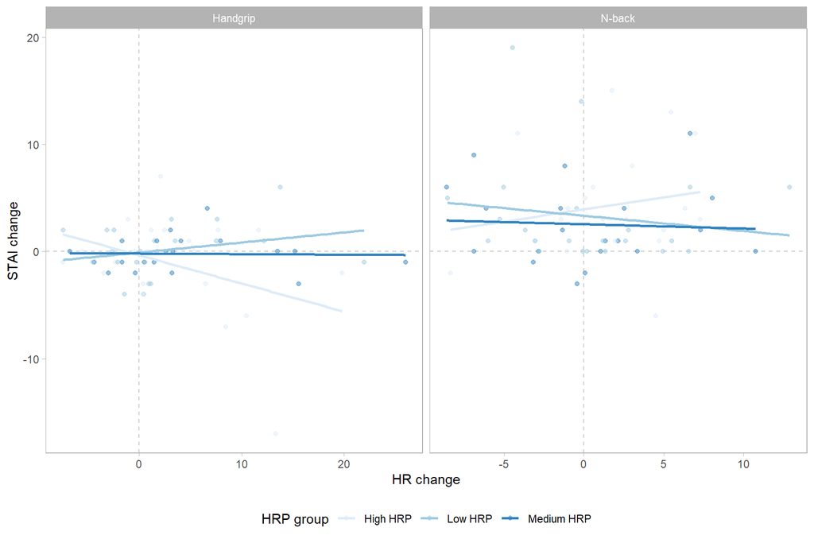

```r
reactivity %>%
  select(id, `meanhr_react_N-back`, meanhr_react_Handgrip,
        `stai_react_N-back`, stai_react_Handgrip) %>%
  left_join(select(experiment, id, ca, hrp, hrp_group), by = "id") %>%
  pivot_longer(`meanhr_react_N-back`:stai_react_Handgrip,
                names_to = c("name", "task"),
                names_pattern = "(.*_react)_(.*)") %>%
  pivot_wider(names_from = "name", values_from = "value") %>%
  ggplot() +
  aes(y = stai_react, x = meanhr_react, color = hrp_group) +
  geom_hline(yintercept = 0, lty = "dashed", alpha = .2) +
  geom_vline(xintercept = 0, lty = "dashed", alpha = .2) +
  geom_point(alpha = .5) +
  geom_smooth(method = "lm", se = FALSE, alpha = .7) +
  scale_color_brewer(palette = "Blues") +
  facet_wrap(~task, scales = "free_x") +
  labs(color = "HRP group",
       x = "HR change",
       y = "STAI change") +
  theme(legend.position = "bottom", panel.grid = element_blank())
```

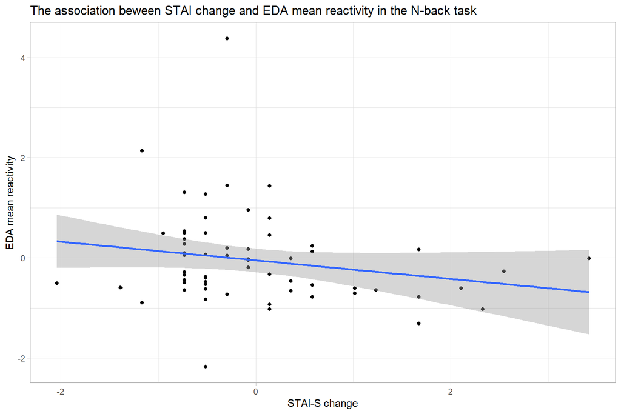

```r
hypo2 %>%
   filter(metric_task %in% c("eda.avg_N-back") &
          str_detect(name, "ca")) %>%
   select(-value) %>%
   unnest(data) %>%
   ggplot() +
   aes(x = `stai_react_N-back`, y = value) +
   geom_point() +
   geom_smooth(method = "lm") +
   labs(title = "The association beween STAI change and EDA mean reactivity in the N-back task",
        x = "STAI-S change",
        y = "EDA mean reactivity")
```

## H3

Perceived stress in both conditions [mental_experienced_stress; physical_experienced_stress / STAI-S_mental_after – STAI-S_mental_before; STAI-S_physical_after - STAI-S_physical_before] is predicted by cardioceptive accuracy [cardioceptive_accuracy], physiological reactions [ΔHRmental, SCRmental, ΔRMSSDmental, ΔHFmental; ΔHRphysical, SCRphysical, ΔRMSSDphysical, ΔHFphysical], and stress related expectations [mental_expected_stress; physical_expected_stress]

We fitted linear regressions for each task (N-back and physical) separately. We investigated if physiological changes, cardioceptive accuracy, or expected HR change predicted STAI-S change in the respective tasks. We used task order as a covariate.

```r
hypo3 <-
   reactivity %>%
   left_join(select(experiment,
                    id, ca, hrp,
                    task_order,
                    physical_expected_hr_change,
                    mental_expected_hr_change),
                    by = "id") %>%
   pivot_longer(`meanhr_react_N-back`:eda.avg_react_Handgrip,
                names_pattern = "(.*)_react_(.*)",
                names_to = c("metric", "task")) %>%
   group_by(metric, task) %>%
   # Scale all numeric vaiarables (by metric and task)
   mutate(across(c(`stai_react_N-back`:hrp,
                 physical_expected_hr_change:mental_expected_hr_change,
                 value),
                 ~scale(.x) %>%
                  as.numeric())) %>%
   nest() %>%
   mutate(`N-back_stai_react_ca` = map(data,
                                     ~lm(`stai_react_N-back` ~ ca +
                                         mental_expected_hr_change +
                                         task_order +
                                         value,
                                         data = .x)),
          Handgrip_stai_react_ca = map(data,
                                     ~lm(stai_react_Handgrip ~ ca +
                                         physical_expected_hr_change +
                                         task_order +
                                         value,
                                         data = .x)),
          `N-back_stai_react_hrp` = map(data,
                                     ~lm(`stai_react_N-back` ~ hrp +
                                         mental_expected_hr_change +
                                         task_order +
                                         value,
                                         data = .x)),
          Handgrip_stai_react_hrp = map(data,
                                     ~lm(stai_react_Handgrip ~ hrp +
                                         physical_expected_hr_change +
                                         task_order +
                                         value,
                                         data = .x))) %>%
   pivot_longer(`N-back_stai_react_ca`:Handgrip_stai_react_hrp) %>%
   filter((str_detect(task, "N-back") & str_detect(name, "N-back")) |
          (str_detect(task, "Handgrip") & str_detect(name, "Handgrip"))) %>%
   mutate(name = str_replace(name, "N-back", task)) %>%
   mutate(name = str_replace(name, "react", metric)) %>%
   ungroup()

hypo3 %>%
   pull(value) %>%
   set_names(hypo3$name) %>%
   map_dfr(tidy, conf.int = TRUE, .id = "model") %>%
   group_by(model) %>%
   mutate(metric = str_match(model, ".*_(.*)_.*$")[,2],
          term = str_replace(term, "value", metric)) %>%
   select(model, term, estimate, std.error, conf.low, conf.high, statistic, p.value) %>%
   # mutate(p.value = p.adjust(p.value, method = "fdr")) %>%
   gt() %>%
   fmt_number(c("estimate", "std.error", "conf.low", "conf.high"), decimals = 2) %>%
   fmt_number(c("statistic", "p.value"), decimals = 3) %>%
   tab_options(column_labels.font.weight = "bold",
               column_labels.background.color = "lightgrey",
               row_group.background.color = "lightgrey",
               row_group.font.weight = "bold",
               row.striping.include_table_body = TRUE,
               row.striping.background_color = "#EEEEEE"
   )
```

| term | estimate | std.error | conf.low | conf.high | statistic | p.value |
| --- | --- | --- | --- | --- | --- | --- |
| N-back_stai_meanhr_ca |  |  |  |  |  |  |
| (Intercept) | −0.16 | 0.17 | −0.50 | 0.18 | −0.943 | 0.350 |
| ca | 0.01 | 0.13 | −0.24 | 0.26 | 0.068 | 0.946 |
| mental_expected_hr_change | 0.27 | 0.13 | 0.00 | 0.53 | 2.037 | 0.046 |
| task_orderPhysical first | 0.38 | 0.27 | −0.15 | 0.92 | 1.433 | 0.157 |
| meanhr | 0.03 | 0.13 | −0.23 | 0.29 | 0.209 | 0.835 |
| N-back_stai_meanhr_hrp |  |  |  |  |  |  |
| (Intercept) | −0.16 | 0.17 | −0.50 | 0.18 | −0.941 | 0.351 |
| hrp | −0.06 | 0.13 | −0.32 | 0.20 | −0.482 | 0.632 |
| mental_expected_hr_change | 0.26 | 0.13 | −0.01 | 0.53 | 1.934 | 0.058 |
| task_orderPhysical first | 0.38 | 0.27 | −0.15 | 0.91 | 1.427 | 0.159 |
| meanhr | 0.04 | 0.13 | −0.22 | 0.30 | 0.276 | 0.783 |
| Handgrip_stai_meanhr_ca |  |  |  |  |  |  |
| (Intercept) | −0.02 | 0.17 | −0.37 | 0.32 | −0.138 | 0.891 |
| ca | −0.02 | 0.13 | −0.28 | 0.24 | −0.162 | 0.872 |
| physical_expected_hr_change | 0.01 | 0.14 | −0.27 | 0.28 | 0.059 | 0.953 |
| task_orderPhysical first | 0.04 | 0.28 | −0.52 | 0.60 | 0.148 | 0.883 |
| meanhr | −0.12 | 0.13 | −0.38 | 0.15 | −0.899 | 0.372 |
| Handgrip_stai_meanhr_hrp |  |  |  |  |  |  |
| (Intercept) | −0.01 | 0.17 | −0.35 | 0.32 | −0.084 | 0.934 |
| hrp | −0.25 | 0.13 | −0.51 | 0.01 | −1.948 | 0.056 |
| physical_expected_hr_change | −0.02 | 0.13 | −0.29 | 0.25 | −0.158 | 0.875 |
| task_orderPhysical first | 0.02 | 0.27 | −0.52 | 0.55 | 0.065 | 0.948 |
| meanhr | −0.09 | 0.13 | −0.35 | 0.17 | −0.666 | 0.508 |
| N-back_stai_hf.percent_ca |  |  |  |  |  |  |
| (Intercept) | −0.13 | 0.17 | −0.47 | 0.21 | −0.782 | 0.437 |
| ca | 0.00 | 0.13 | −0.26 | 0.25 | −0.029 | 0.977 |
| mental_expected_hr_change | 0.30 | 0.14 | 0.02 | 0.57 | 2.172 | 0.034 |
| task_orderPhysical first | 0.36 | 0.26 | −0.17 | 0.88 | 1.357 | 0.180 |
| hf.percent | 0.03 | 0.13 | −0.24 | 0.29 | 0.192 | 0.849 |

[output cut: 66 more lines]

```r
# hypo3 %>%
#    pull(value) %>%
#    set_names(hypo3$name) %>%
#    map_dfr(glance, conf.int = TRUE, .id = "model") %>%
#    arrange(model) %>%
#    gt() %>%
#    fmt_number(c(r.squared:statistic, logLik:deviance), decimals = 2) %>%
#    fmt_number(p.value, decimals = 3)
```

## H4

Perceived HR in both conditions [mental_experienced_HR_change; physical_experienced_HR_change] is predicted by actual change [ΔHRmental, ΔHRphysical] and HR-related expectations [mental_expected_HR_change; physical_expected_HR_change] in both conditions

We fitted linear regressions for each task (cognitive and physical) separately. We investigated if actual (ECG measured) HR change in the respective tasks predicted subjective HR change, and if expectations predicted subjective HR change better. We included sex, body fat percent, and task order as covariates.

We found that actual HR change did not predict the experienced HR change in any of the tasks. However, expected HR change significantly predicted subjective HR change in all tasks.

```r
# Build models
hypo4 <-
   reactivity %>%
   select(id, starts_with("meanhr_")) %>%
   # Put HR reactivity metrics expected and experienced change together
   left_join(select(experiment, id,
                    physical_expected_hr_change,
                    physical_experienced_hr_change,
                    mental_expected_hr_change,
                    mental_experienced_hr_change,
                    bodyfat_percent, sex, task_order), by = "id") %>%
   # Create a redundant dataset to run several regressions at once
   pivot_longer(c(`meanhr_react_N-back`:meanhr_react_Handgrip),
                names_to = c("metric","task"),
                names_pattern = "(.*)_react_(.*)",
                values_to = "hr_reactivity") %>%
      group_by(metric, task) %>%
   # Scale all numeric vaiarables (by metric and task)
   mutate(across(c(physical_expected_hr_change:bodyfat_percent, hr_reactivity),
                 ~scale(.x) %>%
                  as.numeric())) %>%
   nest() %>%
   # Create different models with and without expected variable
   mutate(Handgrip_by_expected = map(data,
                            ~lm(physical_experienced_hr_change ~
                                physical_expected_hr_change +
                                bodyfat_percent + sex + task_order,
                                data = .x)),
          `N-back_by_expected` = map(data,
                            ~lm(mental_experienced_hr_change ~
                                mental_expected_hr_change +
                                bodyfat_percent + sex + task_order,
                                data = .x)),
          Handgrip_by_react = map(data,
                            ~lm(physical_experienced_hr_change ~
                                hr_reactivity +
                                bodyfat_percent + sex + task_order,
                                data = .x)),
          `N-back_by_react` = map(data,
                            ~lm(mental_experienced_hr_change ~
                                hr_reactivity +
                                bodyfat_percent + sex + task_order,
                                data = .x))
          ) %>%
   pivot_longer(Handgrip_by_expected:`N-back_by_react`) %>%
   filter((str_detect(task, "N-back") & str_detect(name, "N-back")) |
          (str_detect(task, "Handgrip") & str_detect(name, "Handgrip"))) %>%
   mutate(name = str_replace(name, "N-back", task)) %>%
   ungroup()

hypo4 %>%
   pull(value) %>%
   set_names(hypo4$name) %>%
   map(tidy, conf.int = TRUE) %>%
   bind_rows(.id = "model") %>%
   group_by(model) %>%
   select(model, term, estimate, std.error, conf.low, conf.high, statistic, p.value) %>%
   # mutate(p.value = p.adjust(p.value, method = "fdr")) %>%
   gt() %>%
   fmt_number(c("estimate", "std.error", "conf.low", "conf.high"), decimals = 2) %>%
   fmt_number(c("statistic", "p.value"), decimals = 3) %>%
   tab_options(column_labels.font.weight = "bold",
               column_labels.background.color = "lightgrey",
               row_group.background.color = "lightgrey",
               row_group.font.weight = "bold",
               row.striping.include_table_body = TRUE,
               row.striping.background_color = "#EEEEEE"
   )
```

| term | estimate | std.error | conf.low | conf.high | statistic | p.value |
| --- | --- | --- | --- | --- | --- | --- |
| N-back_by_expected |  |  |  |  |  |  |
| (Intercept) | −0.02 | 0.22 | −0.46 | 0.43 | −0.071 | 0.943 |
| mental_expected_hr_change | 0.47 | 0.12 | 0.24 | 0.71 | 3.974 | 0.000 |
| bodyfat_percent | 0.19 | 0.15 | −0.12 | 0.50 | 1.236 | 0.222 |
| sexMale | −0.02 | 0.31 | −0.63 | 0.59 | −0.064 | 0.950 |
| task_orderPhysical first | 0.03 | 0.23 | −0.44 | 0.50 | 0.119 | 0.906 |
| N-back_by_react |  |  |  |  |  |  |
| (Intercept) | 0.24 | 0.24 | −0.23 | 0.72 | 1.019 | 0.312 |
| hr_reactivity | 0.09 | 0.13 | −0.17 | 0.36 | 0.691 | 0.492 |
| bodyfat_percent | 0.08 | 0.17 | −0.27 | 0.43 | 0.473 | 0.638 |
| sexMale | −0.35 | 0.34 | −1.02 | 0.33 | −1.023 | 0.311 |
| task_orderPhysical first | −0.15 | 0.27 | −0.68 | 0.39 | −0.543 | 0.589 |
| Handgrip_by_expected |  |  |  |  |  |  |
| (Intercept) | 0.27 | 0.22 | −0.17 | 0.72 | 1.229 | 0.224 |
| physical_expected_hr_change | 0.32 | 0.12 | 0.07 | 0.57 | 2.596 | 0.012 |
| bodyfat_percent | 0.15 | 0.16 | −0.17 | 0.47 | 0.943 | 0.349 |
| sexMale | −0.32 | 0.31 | −0.95 | 0.30 | −1.027 | 0.309 |
| task_orderPhysical first | −0.26 | 0.25 | −0.76 | 0.24 | −1.037 | 0.304 |
| Handgrip_by_react |  |  |  |  |  |  |
| (Intercept) | 0.19 | 0.23 | −0.28 | 0.66 | 0.815 | 0.419 |
| hr_reactivity | 0.09 | 0.13 | −0.17 | 0.34 | 0.677 | 0.501 |
| bodyfat_percent | 0.19 | 0.17 | −0.16 | 0.53 | 1.081 | 0.284 |
| sexMale | −0.29 | 0.33 | −0.95 | 0.37 | −0.867 | 0.389 |
| task_orderPhysical first | −0.12 | 0.26 | −0.64 | 0.40 | −0.471 | 0.639 |

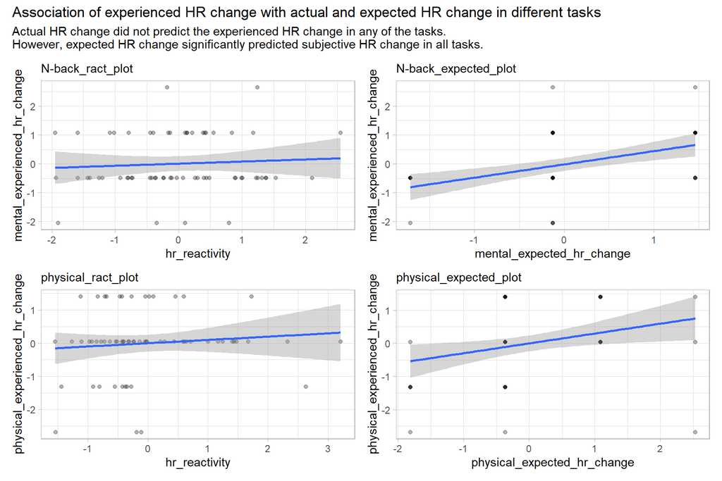

```r
# Plot associations
hypo4_plots <-
   hypo4 %>%
   distinct(task, .keep_all = TRUE) %>%
   select(task, data) %>%
   mutate(physical_ract_plot = map(data,
                                   ~ggplot(.x) +
                                    aes(x = hr_reactivity,
                                        y = physical_experienced_hr_change) +
                                    geom_point(alpha = .3) +
                                    geom_smooth(method = "lm")),
          cognitive_ract_plot = map(data,
                                   ~ggplot(.x) +
                                    aes(x = hr_reactivity,
                                        y = mental_experienced_hr_change) +
                                    geom_point(alpha = .3) +
                                    geom_smooth(method = "lm")),
          physical_expected_plot = map(data,
                                   ~ggplot(.x) +
                                    aes(x = physical_expected_hr_change,
                                        y = physical_experienced_hr_change) +
                                    geom_point(alpha = .3) +
                                    geom_smooth(method = "lm")),
          cognitive_expected_plot = map(data,
                                   ~ggplot(.x) +
                                    aes(x = mental_expected_hr_change,
                                        y = mental_experienced_hr_change) +
                                    geom_point(alpha = .3) +
                                    geom_smooth(method = "lm"))
          ) %>%
   pivot_longer(physical_ract_plot:cognitive_expected_plot,
                values_to = "plots") %>%
   filter((str_detect(task, "N-back") & str_detect(name, "cognitive")) |
          (str_detect(task, "Handgrip") & str_detect(name, "physical"))) %>%
   mutate(name = str_replace(name, "cognitive", task)) %>%
   ungroup() %>%
   mutate(plots = map2(plots, name,
                       ~.x +
                       labs(subtitle = .y)))


wrap_plots(hypo4_plots$plots) +
   plot_annotation(title = "Association of experienced HR change with actual and expected HR change in different tasks",
                   subtitle = "Actual HR change did not predict the experienced HR change in any of the tasks.\nHowever, expected HR change significantly predicted subjective HR change in all tasks.")
```

## H5

Acuity of perception of heartbeat [cardioceptive_bias] and heart rate [cardioceptive_accuracy_HR] are positively associated

There is a positive correlation between cardioceptive accuracy, caridoceptive bias, but not between cardioceptive metrics and heart rate perception.

```r
phys_trans %>%
   distinct(id, .keep_all = TRUE) %>%
   correlation(
               select = c("ca", "hrp"),
               p_adjust = "none")
```

```
## # Correlation Matrix (pearson-method)
##
## Parameter1 | Parameter2 |    r |        95% CI | t(62) |     p
## --------------------------------------------------------------
## ca         |        hrp | 0.19 | [-0.06, 0.41] |  1.51 | 0.136
##
## p-value adjustment method: none
## Observations: 64
```

# Misc

## Correlation of STAI and phys reactivity measures

```r
n_back_corr <-
  reactivity %>%
  correlation(select = c("meanhr_react_N-back", "hf.percent_react_N-back",
                         "rmssd_react_N-back", "eda.avg_react_N-back"),
              select2 = "stai_react_N-back",
              p_adjust = "none") %>%
  summary() %>%
  as_tibble() %>%
  mutate(Parameter = str_remove(Parameter, "_react_N-back"))

handgrip_corr <-
  reactivity %>%
  correlation(select = c("meanhr_react_Handgrip", "hf.percent_react_Handgrip",
                         "rmssd_react_Handgrip", "eda.avg_react_Handgrip"),
              select2 = "stai_react_Handgrip",
              p_adjust = "none") %>%
  summary() %>%
  as_tibble() %>%
  mutate(Parameter = str_remove(Parameter, "_react_Handgrip"))


left_join(n_back_corr, handgrip_corr,
          by = "Parameter") %>%
  left_join(phys_metrics, by = c("Parameter" = "name")) %>%
  transmute(metric,
            `N-back` = round(`stai_react_N-back`, 2),
            Handgrip = stai_react_Handgrip) %>%
  print_html()
```

| metric | N-back | Handgrip |
| --- | --- | --- |
| Mean HR | 0.00 | -0.11 |
| HF% | -0.03 | -0.11 |
| RMSSD | 0.29 | -0.17 |
| Mean EDA | -0.20 | 0.07 |

H4 alternative models

```r
# Build models
hypo4 <-
   reactivity %>%
   select(id, starts_with("meanhr_")) %>%
   # Put HR reactivity metrics expected and experienced change together
   left_join(select(experiment, id,
                    physical_expected_hr_change,
                    physical_experienced_hr_change,
                    mental_expected_hr_change,
                    mental_experienced_hr_change,
                    bodyfat_percent, sex, task_order), by = "id") %>%
   # Create a redundant dataset to run several regressions at once
   pivot_longer(c(`meanhr_react_N-back`:meanhr_react_Handgrip),
                names_to = c("metric","task"),
                names_pattern = "(.*)_react_(.*)",
                values_to = "hr_reactivity") %>%
      group_by(metric, task) %>%
   # Scale all numeric vaiarables (by metric and task)
   mutate(across(c(physical_expected_hr_change:bodyfat_percent, hr_reactivity),
                 ~scale(.x) %>%
                  as.numeric())) %>%
   nest() %>%
   mutate(Handgrip = map(data,
                            ~lm(physical_experienced_hr_change ~
                                physical_expected_hr_change +
                                hr_reactivity +
                                bodyfat_percent + sex + task_order,
                                data = .x)),
          `N-back` = map(data,
                            ~lm(mental_experienced_hr_change ~
                                mental_expected_hr_change +
                                hr_reactivity +
                                bodyfat_percent + sex + task_order,
                                data = .x))
          ) %>%
   pivot_longer(Handgrip:`N-back`) %>%
   filter(task == name) %>%
   ungroup()

hypo4 %>%
   pull(value) %>%
   set_names(hypo4$name) %>%
   map(tidy, conf.int = TRUE) %>%
   bind_rows(.id = "model") %>%
   group_by(model) %>%
   select(model, term, estimate, std.error, conf.low, conf.high, statistic, p.value) %>%
   # mutate(p.value = p.adjust(p.value, method = "fdr")) %>%
   gt() %>%
   fmt_number(c("estimate", "std.error", "conf.low", "conf.high"), decimals = 2) %>%
   fmt_number(c("statistic", "p.value"), decimals = 3) %>%
   tab_options(column_labels.font.weight = "bold",
               column_labels.background.color = "lightgrey",
               row_group.background.color = "lightgrey",
               row_group.font.weight = "bold",
               row.striping.include_table_body = TRUE,
               row.striping.background_color = "#EEEEEE"
   )
```

| term | estimate | std.error | conf.low | conf.high | statistic | p.value |
| --- | --- | --- | --- | --- | --- | --- |
| N-back |  |  |  |  |  |  |
| (Intercept) | −0.02 | 0.22 | −0.47 | 0.42 | −0.104 | 0.918 |
| mental_expected_hr_change | 0.49 | 0.12 | 0.25 | 0.74 | 3.991 | 0.000 |
| hr_reactivity | 0.07 | 0.12 | −0.16 | 0.31 | 0.620 | 0.537 |
| bodyfat_percent | 0.21 | 0.16 | −0.11 | 0.53 | 1.341 | 0.185 |
| sexMale | −0.03 | 0.31 | −0.65 | 0.60 | −0.089 | 0.929 |
| task_orderPhysical first | 0.03 | 0.24 | −0.46 | 0.52 | 0.126 | 0.900 |
| Handgrip |  |  |  |  |  |  |
| (Intercept) | 0.28 | 0.23 | −0.17 | 0.74 | 1.245 | 0.218 |
| physical_expected_hr_change | 0.31 | 0.13 | 0.06 | 0.57 | 2.483 | 0.016 |
| hr_reactivity | 0.07 | 0.12 | −0.17 | 0.32 | 0.592 | 0.556 |
| bodyfat_percent | 0.15 | 0.16 | −0.18 | 0.48 | 0.917 | 0.363 |
| sexMale | −0.33 | 0.32 | −0.96 | 0.31 | −1.026 | 0.309 |
| task_orderPhysical first | −0.28 | 0.26 | −0.80 | 0.23 | −1.103 | 0.275 |

## HBP and HRP corr figure

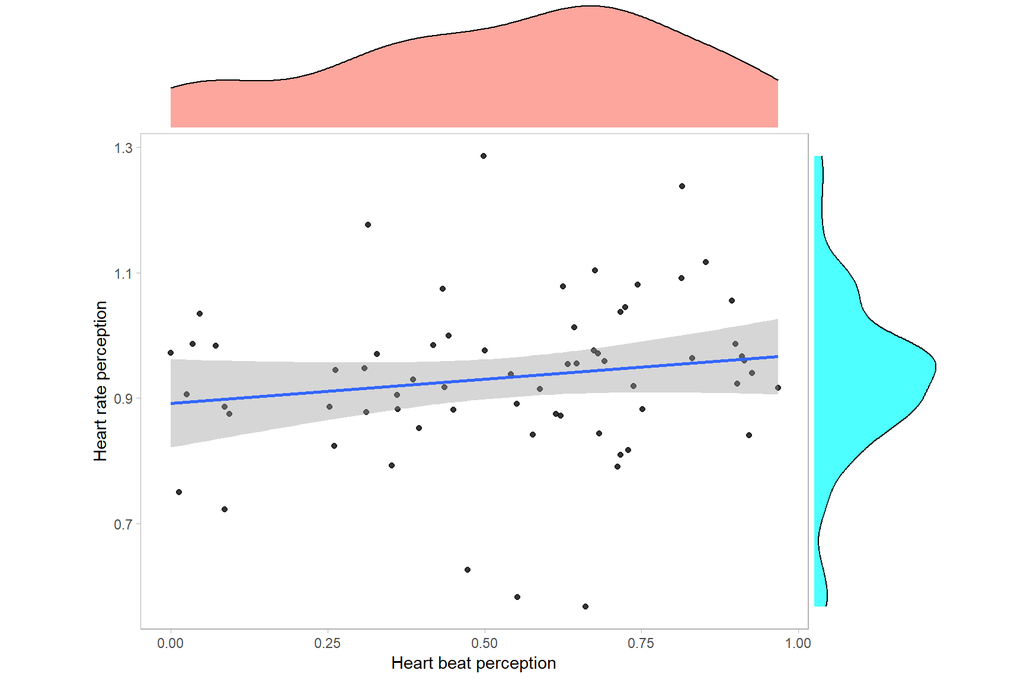

```r
hrp_hbp <-
  experiment %>%
  select(hrp, ca) %>%
  ggplot() +
  aes(x = ca, y = hrp) +
  geom_point(alpha = .8) +
  geom_smooth(method = lm) +
  labs(x = "Heart beat perception",
       y = "Heart rate perception") +
  theme(panel.grid = element_blank()) +
  coord_fixed(ratio = 1)


ggExtra::ggMarginal(hrp_hbp, type = "density", alpha = .7,
                    xparams = list(fill = "salmon"),
                    yparams = list(fill = "cyan")
                    )
```

## Create path diagram

```r
# Prepare data

path_df <-
   reactivity %>%
   select(id, starts_with("meanhr_"),
          stai_react_Handgrip,
          `stai_react_N-back`) %>%
   # Put HR reactivity metrics expected and experienced change together
   left_join(select(experiment,
                    id, bodyfat_percent, sex, task_order, hrp,
                    `expectedhr_change_Handgrip` = physical_expected_hr_change,
                    `experiencedhr_change_Handgrip` = physical_experienced_hr_change,
                    `expectedhr_change_N-back` = mental_expected_hr_change,
                    `experiencedhr_change_N-back` = mental_experienced_hr_change),
             by = "id") %>%
   # Create a redundant dataset to run several regressions at once
   pivot_longer(cols = -c("id", "bodyfat_percent", "sex", "task_order", "hrp"),
                names_to = c("metric","task"),
                names_pattern = "^(.*)_.*_(.*)",
                values_to = "value") %>%
  pivot_wider(names_from = "metric",
              values_from = "value")
```

```r
# Create path models

library(lavaan)
library(tidySEM)
library(semTable)

hr_model <-
  "stai ~ expectedhr
   stai ~ experiencedhr
   stai ~ meanhr
   stai ~ task_order
   experiencedhr ~ expectedhr
   experiencedhr ~ meanhr
   experiencedhr ~ task_order
   expectedhr ~ task_order
   meanhr ~ expectedhr
   meanhr ~ task_order + sex + bodyfat_percent
"

# Fit model in lavaan
hr_path <- sem(model = hr_model, data = path_df, group = "task")

# tidySEM way of building and running sem
model <-
  tidy_sem(path_df) %>%
  add_paths(hr_model)

fit_model <-
  model %>%
  estimate_lavaan()

# Return results
summary(hr_path, standardized = TRUE, fit.measures = TRUE)
```

```
## lavaan 0.6-12 ended normally after 160 iterations
##
##   Estimator                                         ML
##   Optimization method                           NLMINB
##   Number of model parameters                        40
##
##   Number of observations per group:               Used       Total
##     N-back                                          62          64
##     Handgrip                                        63          64
##
## Model Test User Model:
##
##   Test statistic                                28.233
##   Degrees of freedom                                12
##   P-value (Chi-square)                           0.005
##   Test statistic for each group:
##     N-back                                      13.496
##     Handgrip                                    14.737
##
## Model Test Baseline Model:
##
##   Test statistic                                82.405
##   Degrees of freedom                                36
##   P-value                                        0.000
##
## User Model versus Baseline Model:
##
##   Comparative Fit Index (CFI)                    0.650
##   Tucker-Lewis Index (TLI)                      -0.049
##
## Loglikelihood and Information Criteria:
##
##   Loglikelihood user model (H0)               -968.144
##   Loglikelihood unrestricted model (H1)             NA
##
##   Akaike (AIC)                                2016.288
##   Bayesian (BIC)                              2129.420
##   Sample-size adjusted Bayesian (BIC)         2002.933
##
## Root Mean Square Error of Approximation:
```

[output cut: 72 more lines]

```
##     bodyfat_percnt    0.093    0.153    0.612    0.541    0.093    0.102
##
## Intercepts:
##                    Estimate  Std.Err  z-value  P(>|z|)   Std.lv  Std.all
##    .stai             -0.381    3.693   -0.103    0.918   -0.381   -0.118
##    .experiencedhr     3.351    0.680    4.931    0.000    3.351    4.567
##    .expectedhr        4.701    0.252   18.680    0.000    4.701    6.878
##    .meanhr           -4.433    9.206   -0.481    0.630   -4.433   -0.634
##
## Variances:
##                    Estimate  Std.Err  z-value  P(>|z|)   Std.lv  Std.all
##    .stai             10.260    1.828    5.612    0.000   10.260    0.986
##    .experiencedhr     0.482    0.086    5.612    0.000    0.482    0.895
##    .expectedhr        0.432    0.077    5.612    0.000    0.432    0.925
##    .meanhr           47.681    8.496    5.612    0.000   47.681    0.976
```

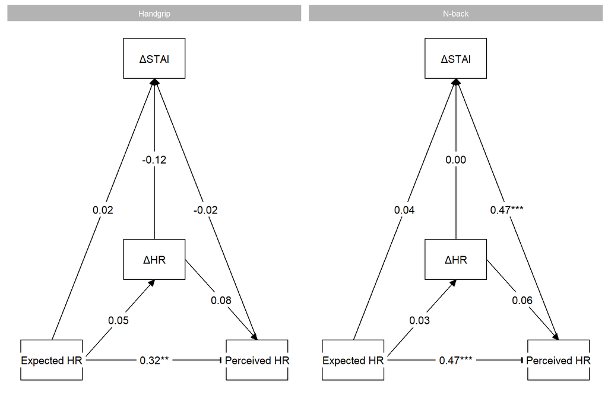

```r
# Plotting SEM
# Format node labels
pretty_nodes <-
  get_nodes(hr_path, label = "name") %>%
  mutate(label = recode(label,
                        expectedhr = "Expected HR",
                        experiencedhr = "Perceived HR",
                        stai = "ΔSTAI",
                        meanhr = "ΔHR")) %>%
  # Remove confounders
  filter(!str_detect(name, "task_order|sex|bodyfat_percent"))

pretty_edges <-
                  # Format edges (to std)
  get_edges(hr_path, label = "est_sig_std") %>%
                  # Remove variances
                  filter(op != "~~",
                  # Remove confounders
                         !str_detect(lhs, "task_order|sex|bodyfat_percent"),
                         !str_detect(rhs, "task_order|sex|bodyfat_percent"))


# Create a layout
layout <- get_layout("", "stai", "",
                     "", "", "",
                     "", "meanhr", "",
                     "expectedhr", "", "experiencedhr",
                     rows = 4)

# Plotting SEM
graph_sem(hr_path,
          edges = pretty_edges,
          nodes = pretty_nodes,
          layout = layout
          )
```

```r
# semTable(hr_path, type = "html") # %>% write_lines("docs/s4.html")
```